# Term Deposit Sale

```python
import pandas as pd                                             # library for working with dataframes
import numpy as np                                              # library for working with arrays
import matplotlib.pyplot as plt                                 # low level visualization library
%matplotlib inline
import seaborn as sns                                           # higher level visualization library compared to matplotlib
from sklearn.model_selection import train_test_split
from sklearn.tree import DecisionTreeClassifier
from sklearn.metrics import accuracy_score, f1_score, recall_score, precision_score, confusion_matrix, roc_auc_score
from IPython.display import Image
import pydotplus as pydot
from sklearn import tree
from os import system

from yellowbrick.classifier import ClassificationReport, ROCAUC
plt.style.use('ggplot')
pd.options.display.float_format = '{:,.2f}'.format
from IPython.core.display import display, HTML
display(HTML("<style>.container { width:95% !important; }</style>"))
```

```python
# read the csv file into a dataframe
df=pd.read_csv("bank-full.csv")
```

Bank client data:

1. age: Continuous feature
2. job: Type of job (management, technician, entrepreneur, blue-collar, etc.)
3. marital: marital status (married, single, divorced)
4. education: education level (primary, secondary, tertiary)
5. default: has credit in default?
6. housing: has housing loan?
7. loan: has personal loan?
8. balance in account Related to previous contact:
9. contact: contact communication type
10. month: last contact month of year
11. day: last contact day of the month
12. duration: last contact duration, in seconds* Other attributes:
13. campaign: number of contacts performed during this campaign and for this client
14. pdays: number of days that passed by after the client was last contacted from a previous campaign (-1 tells us the person has not been contacted or contact period is beyond 900 days)
15. previous: number of contacts performed before this campaign and for this client
16. poutcome: outcome of the previous marketing campaign Output variable (desired target):
17. Target: Tell us has the client subscribed a term deposit. (Yes, No)

# Deliverable - 1 Exploratory Data Quality report

### 1 Univariate Analysis (12 )

```python
df.head()
# Target is our dependent variable , rest are the independent variables.
```

|  | age | job | marital | education | default | balance | housing | loan | contact | day | month | duration | campaign | pdays | previous | poutcome | Target |
| --- | --- | --- | --- | --- | --- | --- | --- | --- | --- | --- | --- | --- | --- | --- | --- | --- | --- |
| 0 | 58 | management | married | tertiary | no | 2143 | yes | no | unknown | 5 | may | 261 | 1 | -1 | 0 | unknown | no |
| 1 | 44 | technician | single | secondary | no | 29 | yes | no | unknown | 5 | may | 151 | 1 | -1 | 0 | unknown | no |
| 2 | 33 | entrepreneur | married | secondary | no | 2 | yes | yes | unknown | 5 | may | 76 | 1 | -1 | 0 | unknown | no |
| 3 | 47 | blue-collar | married | unknown | no | 1506 | yes | no | unknown | 5 | may | 92 | 1 | -1 | 0 | unknown | no |
| 4 | 33 | unknown | single | unknown | no | 1 | no | no | unknown | 5 | may | 198 | 1 | -1 | 0 | unknown | no |

#### 1.a Checking for number of rows and coloumns in the database

```python
df.shape
#there are 45211 rows and 17 columns in the dataframe.
```

```
(45211, 17)
```

```python
df.info()
# There are continous and non continous  variables in the dataframe
# age, balance, day, duration, campaign, pdays, previous are continous variables.
```

```
<class 'pandas.core.frame.DataFrame'>
RangeIndex: 45211 entries, 0 to 45210
Data columns (total 17 columns):
 #   Column     Non-Null Count  Dtype
---  ------     --------------  -----
 0   age        45211 non-null  int64
 1   job        45211 non-null  object
 2   marital    45211 non-null  object
 3   education  45211 non-null  object
 4   default    45211 non-null  object
 5   balance    45211 non-null  int64
 6   housing    45211 non-null  object
 7   loan       45211 non-null  object
 8   contact    45211 non-null  object
 9   day        45211 non-null  int64
 10  month      45211 non-null  object
 11  duration   45211 non-null  int64
 12  campaign   45211 non-null  int64
 13  pdays      45211 non-null  int64
 14  previous   45211 non-null  int64
 15  poutcome   45211 non-null  object
 16  Target     45211 non-null  object
dtypes: int64(7), object(10)
memory usage: 5.9+ MB
```

```python
df.describe().transpose()
#Observations
# Average age is around 40-41
# Average balance in accound is 1362 and there are members with negative balance.
# Here we have mean , median , quartiles etc.  of all continous variables

# There are no missing values in the continous variable columns because all the
# continous variables got listed in five point summary and none of the values are
# a string.
```

|  | count | mean | std | min | 25% | 50% | 75% | max |
| --- | --- | --- | --- | --- | --- | --- | --- | --- |
| age | 45,211.00 | 40.94 | 10.62 | 18.00 | 33.00 | 39.00 | 48.00 | 95.00 |
| balance | 45,211.00 | 1,362.27 | 3,044.77 | -8,019.00 | 72.00 | 448.00 | 1,428.00 | 102,127.00 |
| day | 45,211.00 | 15.81 | 8.32 | 1.00 | 8.00 | 16.00 | 21.00 | 31.00 |
| duration | 45,211.00 | 258.16 | 257.53 | 0.00 | 103.00 | 180.00 | 319.00 | 4,918.00 |
| campaign | 45,211.00 | 2.76 | 3.10 | 1.00 | 1.00 | 2.00 | 3.00 | 63.00 |
| pdays | 45,211.00 | 40.20 | 100.13 | -1.00 | -1.00 | -1.00 | -1.00 | 871.00 |
| previous | 45,211.00 | 0.58 | 2.30 | 0.00 | 0.00 | 0.00 | 0.00 | 275.00 |

#### 1.a Finiding if there are any null values

```python
df.isnull().values.any()
# There are no null values in the dataframe.
```

```
False
```

```python
# Listing all unique values
df_unique = df.nunique().to_frame().reset_index()
df_unique.columns = ['Variable','DistinctCount']
print(df_unique)
```

```
     Variable  DistinctCount
0         age             77
1         job             12
2     marital              3
3   education              4
4     default              2
5     balance           7168
6     housing              2
7        loan              2
8     contact              3
9         day             31
10      month             12
11   duration           1573
12   campaign             48
13      pdays            559
14   previous             41
15   poutcome              4
16     Target              2
```

#### 1a. Checking charateristics of the independent variables.

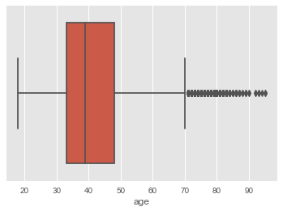

```python
# Age Box plot
sns.boxplot(x=df['age'])
```

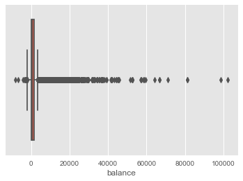

```python
# Balance Box plot
sns.boxplot(x=df['balance'])
#There are outliers in the balance data.
```

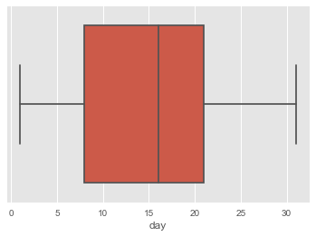

```python
# Day Box plot
sns.boxplot(x=df['day'])
```

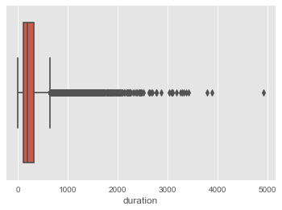

```python
# duration Box plot
sns.boxplot(x=df['duration'])
#There are outliers in duration
```

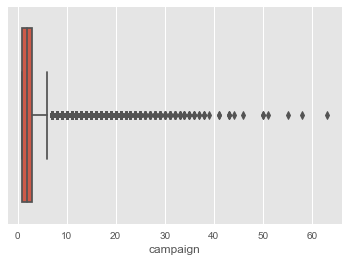

```python
# campaign Box plot
sns.boxplot(x=df['campaign'])
#There are outliers in campaign data
```

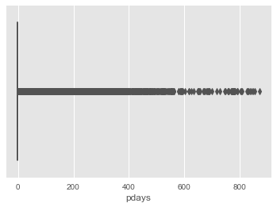

```python
# pdays Box plot
sns.boxplot(x=df['pdays'])
#pdays is highly skewed
```

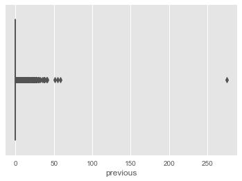

```python
# pdays Box plot
sns.boxplot(x=df['previous'])
#previous is highly skewed
```

```python
df['pdays'].value_counts(normalize= True)
#pdays is highly skewed out of 45211 values 36954 has a
#value -1 (-1 tells us the person has not been contacted or contact period is beyond 900 days)
```

```
-1     0.82
 182   0.00
 92    0.00
 183   0.00
 91    0.00
       ...
 749   0.00
 717   0.00
 589   0.00
 493   0.00
 32    0.00
Name: pdays, Length: 559, dtype: float64
```

```python
df['previous'].value_counts(normalize=True)
#previous is highly skewed out of 45211 values 36954 has a value 0
```

```
0     0.82
1     0.06
2     0.05
3     0.03
4     0.02
5     0.01
6     0.01
7     0.00
8     0.00
9     0.00
10    0.00
11    0.00
12    0.00
13    0.00
15    0.00
```

[output cut: 27 more lines]

```python
# dropping pdays and previous from the dataframe

df.drop(['pdays','previous'], axis=1,inplace = True)
df.head()
```

|  | age | job | marital | education | default | balance | housing | loan | contact | day | month | duration | campaign | poutcome | Target |
| --- | --- | --- | --- | --- | --- | --- | --- | --- | --- | --- | --- | --- | --- | --- | --- |
| 0 | 58 | management | married | tertiary | no | 2143 | yes | no | unknown | 5 | may | 261 | 1 | unknown | no |
| 1 | 44 | technician | single | secondary | no | 29 | yes | no | unknown | 5 | may | 151 | 1 | unknown | no |
| 2 | 33 | entrepreneur | married | secondary | no | 2 | yes | yes | unknown | 5 | may | 76 | 1 | unknown | no |
| 3 | 47 | blue-collar | married | unknown | no | 1506 | yes | no | unknown | 5 | may | 92 | 1 | unknown | no |
| 4 | 33 | unknown | single | unknown | no | 1 | no | no | unknown | 5 | may | 198 | 1 | unknown | no |

```python
# converting variables to categorical variables
for feature in df.columns:
    if df[feature].dtype == 'object':
        df[feature] = pd.Categorical(df[feature])
df.info()
```

```
<class 'pandas.core.frame.DataFrame'>
RangeIndex: 45211 entries, 0 to 45210
Data columns (total 15 columns):
 #   Column     Non-Null Count  Dtype
---  ------     --------------  -----
 0   age        45211 non-null  int64
 1   job        45211 non-null  category
 2   marital    45211 non-null  category
 3   education  45211 non-null  category
 4   default    45211 non-null  category
 5   balance    45211 non-null  int64
 6   housing    45211 non-null  category
 7   loan       45211 non-null  category
 8   contact    45211 non-null  category
 9   day        45211 non-null  int64
 10  month      45211 non-null  category
 11  duration   45211 non-null  int64
 12  campaign   45211 non-null  int64
 13  poutcome   45211 non-null  category
 14  Target     45211 non-null  category
dtypes: category(10), int64(5)
memory usage: 2.2 MB
```

```python
# examining all categorical varables and its counts
df['job'].value_counts()
```

```
blue-collar      9732
management       9458
technician       7597
admin.           5171
services         4154
retired          2264
self-employed    1579
entrepreneur     1487
unemployed       1303
housemaid        1240
student           938
unknown           288
Name: job, dtype: int64
```

```python
df['marital'].value_counts()
```

```
married     27214
single      12790
divorced     5207
Name: marital, dtype: int64
```

```python
df['education'].value_counts()
```

```
secondary    23202
tertiary     13301
primary       6851
unknown       1857
Name: education, dtype: int64
```

```python
df['default'].value_counts()
```

```
no     44396
yes      815
Name: default, dtype: int64
```

```python
df['housing'].value_counts()
```

```
yes    25130
no     20081
Name: housing, dtype: int64
```

```python
df['loan'].value_counts()
```

```
no     37967
yes     7244
Name: loan, dtype: int64
```

```python
df['contact'].value_counts()
```

```
cellular     29285
unknown      13020
telephone     2906
Name: contact, dtype: int64
```

```python
df['month'].value_counts()
# most of the people where contacted in the month May.
# Dec, Mar, Sep ,Oct saw least contacted month
```

```
may    13766
jul     6895
aug     6247
jun     5341
nov     3970
apr     2932
feb     2649
jan     1403
oct      738
sep      579
mar      477
dec      214
Name: month, dtype: int64
```

```python
df['poutcome'].value_counts()
```

```
unknown    36959
failure     4901
other       1840
success     1511
Name: poutcome, dtype: int64
```

```python
df['Target'].value_counts()
```

```
no     39922
yes     5289
Name: Target, dtype: int64
```